# Enrocamento Vegetado

Bioengenharia de Solos

Prof. Dr. Luiz Diego Vidal Santos

## Abertura Visão Geral da Aula

Roteiro da aula Tópicos estruturantes

- 1 O que é enrocamento vegetado?
- 2 Enrocamento convencional × vegetado
- 3 Gradologia de pedras e filtros
- 4 Espécies para estacas vivas
- 5 Projeto e dimensionamento
- 6 Construção e implantação
- 7 Monitoramento e sucessão ecológica
- 8 Síntese e atividade

Objetivo central Proteção pétrea aliada ao reforço vivo

Compreender os princípios do **enrocamento vegetado** (*vegetated riprap*) como técnica de **bioengenharia** que combina a estabilidade estrutural das **pedras** com o enraizamento de **estacas vivas**, aprender a **dimensionar**, **construir** e **monitorar** o sistema para proteção de margens fluviais e bases de taludes.

Equação de Isbash ($D_{50}$) Filtro de Terzaghi Estacas vivas · APP

# O que é enrocamento vegetado?

## Conceito Definição, componentes e evolução temporal

Vegetated riprap / Live riprap Sistema híbrido pedra–solo–raiz

- **Pedras** (enrocamento) para resistência mecânica imediata
- **Solo fértil** nos interstícios para suporte de vida
- **Estacas vivas** (*live stakes*) com propagação vegetativa
- **Raízes** que assumem progressivamente parte da função estrutural

Transforma uma **estrutura inerte** em um **ecossistema vivo**: as raízes entrelaçam os blocos e geram **resiliência ecológica** após cheias e secas.

**Ano 0 · 100% pedras:** blocos lançados com estacas cravadas garantem estabilidade imediata ao fluxo.

**Ano 1 · Enraizamento inicial:** brotação aérea e emissão de raízes nos interstícios preenchidos com solo.

**Anos 2–3 · Entrelaçamento:** raízes amarram as pedras entre si e ancoram o filtro ao talude natural.

**Ano 5+ · 50% pedras + 50% raízes:** sistema vivo autossustentável com rugosidade hidráulica natural.

## Conceito Seção esquemática e aplicações de campo

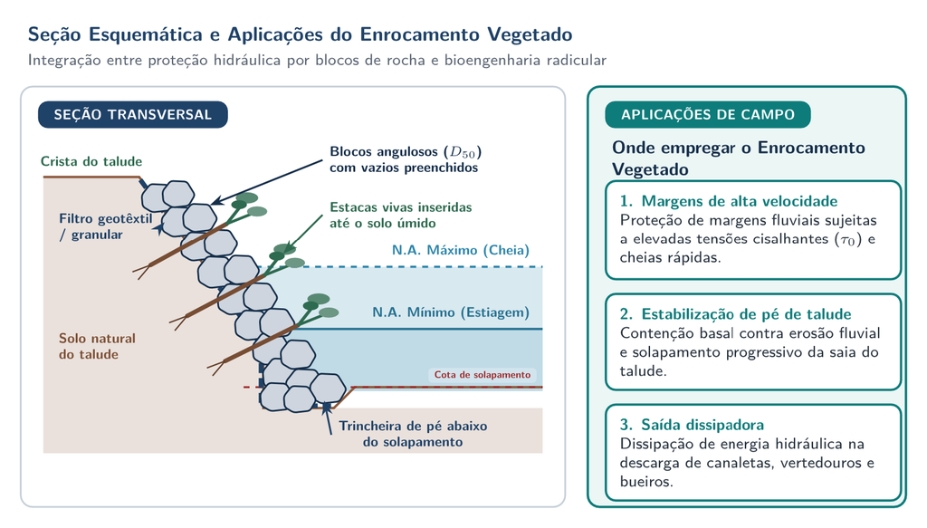

Seção transversal esquemática e aplicações de campo do enrocamento vegetado

Seção transversal e aplicações do enrocamento vegetado Blocos (D₅₀), filtro geotêxtil/granular, trincheira de pé abaixo do solapamento e estacas vivas até o solo úmido

A combinação de trincheira de pé (*toe*) abaixo da cota de solapamento e estacas vivas cravadas até o solo úmido protege o talude nos regimes de estiagem e cheia máxima.

## Conceito Registro de campo e locais de aplicação

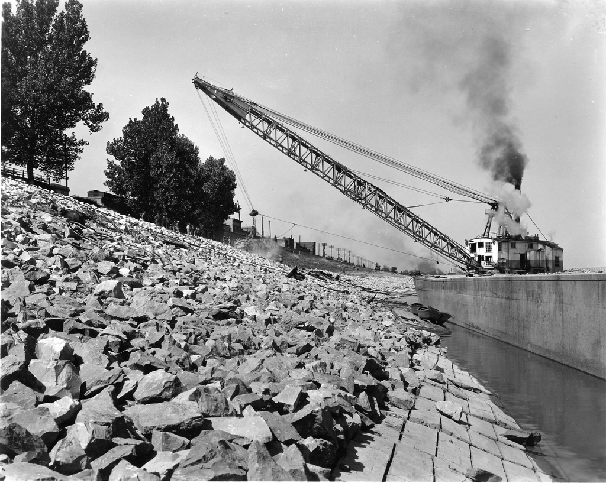

Proteção de margem com riprap no Rio Ohio, Cairo, EUA, em 1935

Enrocamento em margem fluvial — Rio Ohio, 1935 Fonte: USACE Memphis District · Public Domain

| Local de aplicação | Função principal |
| --- | --- |
| Margens de rios / Reservatórios | Proteção fluvial e contra ondas |
| Base de taludes (*toe*) | Contenção basal anti-solapamento |
| Saídas de bueiros e canais | Dissipação de energia e revestimento |
| Trechos costeiros | Proteção litorânea |

Inspeção e conformidade em APP Checklist de campo

Conferir estabilidade dos blocos e do pé, filtro/vazios, erosão nas extremidades e estabelecimento ciliar (**Lei 12.651/2012 — Código Florestal**).

# Enrocamento convencional × vegetado

## Comparação Confronto técnico, ecológico e critérios de decisão

Enrocamento convencional Estrutura inerte · manutenção periódica

Camada de pedras com juntas preenchidas por brita ou argamassa; resistência mecânica imediata (30–50+ anos), sem componente biológico e com alto custo de transporte.

Enrocamento vegetado (*live riprap*) Sistema vivo · 20–40% menor custo

Interstícios preenchidos com **solo fértil** e **estacas vivas**; proporciona autorreparação, habitat aquático/terrestre, filtragem de sedimentos e durabilidade crescente.

| Critério | Convencional | Vegetado |
| --- | --- | --- |
| Fluxo $V > 4\text{ m s}^{-1}$ | ★★★★★ | ★★★☆☆ |
| APP (exigência legal) | ★★☆☆☆ | ★★★★★ |
| Habitat / Paisagem | ★☆☆☆☆ | ★★★★★ |
| Custo inicial / Manutenção LP | ★★☆☆☆ / ★★★☆☆ | ★★★★☆ / ★★★★★ |
| Resistência imediata | ★★★★★ | ★★★★☆ |

Em fluxos **$> 4\text{ m s}^{-1}$** ou ondas **$> 1\text{ m}$**, adote **solução mista**: convencional na base submersa e vegetado acima da cota média.

# Gradologia de pedras e filtros

## Gradologia Equação de Isbash, classes de pedra e filtro de Terzaghi

**Diâmetro característico $D_{50}$ (Isbash, 1936):**

$$D_{50} = \frac{V^2}{2g \cdot C^2 \cdot (\gamma_s / \gamma_w - 1)}$$

Onde $V$ = velocidade (m s⁻¹), $g = 9,81\text{ m s}^{-2}$, $C$ = coef. de Isbash ($0,86$ fundo; $1,20$ talude), $\gamma_s \approx 2.650\text{ kg m}^{-3}$ e $\gamma_w = 1.000\text{ kg m}^{-3}$.

| Classe | $D_{50}$ (cm) | Massa média (kg) | $V_{adm}$ máxima |
| --- | --- | --- | --- |
| Rachão leve | 10–15 | 2–5 | 1,0–1,5 m/s |
| Rachão médio | 15–25 | 5–20 | 1,5–2,5 m/s |
| Rachão pesado | 25–40 | 20–80 | 2,5–3,5 m/s |
| Pedra de mão | 40–60 | 80–300 | 3,5–5,0 m/s |

Transição granulométrica Camada filtrante anti-sufosão

Pedras grandes (externa) $\rightarrow$ Pedras médias (transição) $\rightarrow$ Brita/seixo (filtro granular) $\rightarrow$ Geotêxtil (filtro sintético) $\rightarrow$ Solo natural da margem.

**Regras de filtro de Terzaghi:**

$$\frac{D_{15(\text{filtro})}}{D_{85(\text{solo})}} < 5 \qquad \text{e} \qquad \frac{D_{15(\text{filtro})}}{D_{15(\text{solo})}} > 4$$

Os interstícios **não levam argamassa**, mas sim **solo fértil** para enraizamento das estacas vivas.

# Espécies para estacas vivas

## Espécies Seleção botânica, preparo e taxa de enraizamento

| Espécie | Nome popular | Habitat |
| --- | --- | --- |
| *Salix humboldtiana* | Salgueiro | Margens fluviais |
| *Sebastiania commersoniana* | Branquilho | Mata ciliar |
| *Calliandra brevipes* | Esponjinha | Cerrado úmido |
| *Inga marginata* | Ingá-feijão | Mata Atlântica |
| *Schinus terebinthifolia* | Aroeira-pimenteira | Generalista |
| *Erythrina crista-galli* | Corticeira | Banhados |
| *Phyllanthus sellowianus* | Sarandi | Margens |

Critérios: **propagação vegetativa**, tolerância à submersão periódica, crescimento rápido e raízes densas.

Padrão das estacas Especificações biométricas

- **Diâmetro:** 2–8 cm (ótimo: 3–5 cm) · **Comprimento:** 50–100 cm
- **Cortes:** diagonal na base (cravação) e reto no ápice
- **Coleta e guarda:** ramos em dormência; máx. **48 h** em local úmido e sombreado

Mês 1 10–30%

Início da brotação.

Mês 3 40–60%

Emissão radicular.

Mês 6 70–85%

Ancoragem nos vazios.

Ano 1 80–95%

Sistema consolidado.

# Projeto e dimensionamento

## Projeto Fluxo de dimensionamento e sequência construtiva

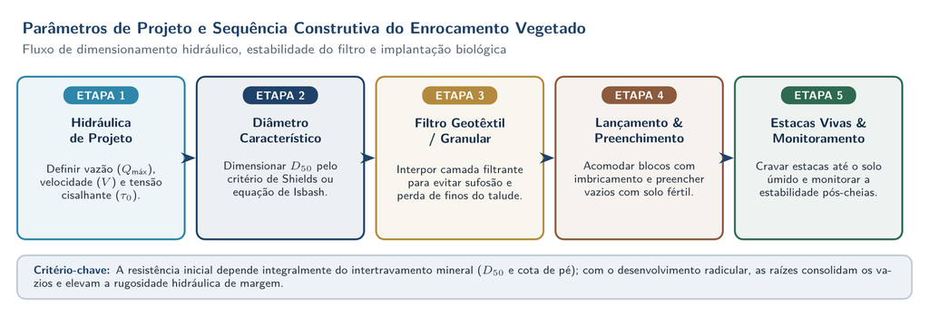

Fluxo em cinco etapas do dimensionamento hidráulico à implantação biológica do enrocamento vegetado

Parâmetros de projeto e sequência construtiva Da hidráulica de projeto (Qmáx, V, τ₀) e D₅₀ ao filtro, imbricamento de blocos, estacas vivas e monitoramento

**Critério-chave:** a resistência inicial depende integralmente do intertravamento mineral ($D_{50}$ e cota de pé); com o avanço radicular, as raízes consolidam os vazios.

## Projeto Geometria da seção, quantitativos e função de cada camada

| Parâmetro geométrico | Valor recomendado |
| --- | --- |
| Espessura mínima | $1,5 \times D_{50}$ ou 30 cm (o maior) |
| Inclinação do talude | 1V:1,5H a 1V:3H |
| Fundação (*toe*) | Enterrar $\ge 60\text{ cm}$ abaixo do leito |
| Coroamento / Extensão | Acima da cheia ($TR = 10$ anos) · $\ge 1\text{ m}$ |

**Densidade de estacas ($2\text{–}4\text{ estacas m}^{-2}$) e volume de pedras:**

$$d_{estacas} = \frac{N}{A_{enroc}} \qquad\qquad V_{pedras} = A_{face} \times e_{camada} \times (1 - n)$$

Onde $n$ = porosidade do enrocamento ($0,35\text{–}0,45$).

**Coroamento:** acima do N.A. de cheia ($TR = 10$ anos) para impedir galgamento erosivo.

**Corpo do enrocamento:** blocos intertravados + solo fértil + estacas vivas.

**Filtro:** camada granular ou geotêxtil contra carreamento de finos.

**Fundação (*toe*):** enterrada $\ge 60\text{ cm}$ com blocos maiores na base — ponto crítico anti-colapso.

# Construção e implantação

## Construção Etapas em obra, cravação de estacas e época de plantio

**1–2 · Leito e filtro:** escavar o *toe*, perfilar o talude e assentar geotêxtil ou filtro granular.

**3–4 · Pedras e solo:** dispor blocos da **base para o topo** (travados, sem lançar do alto) e preencher vazios com solo fértil.

**5–7 · Estacas, mulch e rega:** abrir furo-guia, cravar **2–4 estacas m⁻²** (**2/3 no solo, 1/3 exposta**), compactar ao redor, aplicar *mulch* e irrigar se necessário.

Coletar estacas na **dormência** (reservas de carboidratos), mas plantar no início da **estação úmida**.

| Passo | Inserção da estaca nos interstícios |
| --- | --- |
| 1–2 | Preencher vazio com solo úmido e abrir furo-guia metálico |
| 3–5 | Inserir corte diagonal para baixo, compactar e aplicar *mulch* |

| Região do Brasil | Melhor época de plantio |
| --- | --- |
| Nordeste semiárido | Início das chuvas (mar–abr) |
| Sudeste / Sul | Out–dez / Set–nov |
| Amazônia | Transição seca $\rightarrow$ chuvosa |

# Monitoramento e sucessão ecológica

## Monitoramento Cronograma, metas e fases da sucessão ecológica

| Período | Indicador | Meta |
| --- | --- | --- |
| 15 dias | Brotação das estacas | > 50% |
| 60 dias | Enraizamento inicial | Raízes visíveis |
| 6 meses / 1 ano | Cobertura vegetal | > 40% / > 70% |
| 2 anos | Entrelaçamento raiz–pedra | Consolidação |
| 5 anos | Ecossistema autônomo | Autossustentável |

**Sucesso:** > 80% de estacas brotadas, raízes > 30 cm no solo, blocos imóveis em cheias e retorno de fauna associada.

Fase 1 · 0–2 anos Pioneira

Estacas vivas + gramíneas estabilizadoras.

Fase 2 · 2–5 anos Herbácea

Arbustos e herbáceas espontâneas.

Fase 3 · 5–10 anos Arbustiva

Arbustos densos e árvores jovens.

Fase 4 · 10+ anos Arbórea

Mata ciliar em regeneração plena.

As estacas vivas atuam como **pioneiras**, criando microclima e estrutura para espécies **climácicas** da mata ciliar.

# Síntese e atividade

## Síntese Pontos fundamentais e fluxo conceitual

Resumo técnico Seis pilares do enrocamento vegetado

1. Combina **pedras** (resistência imediata) e **estacas vivas** (reforço biológico)
2. Interstícios preenchidos com **solo fértil**, nunca com argamassa
3. **$D_{50}$** dimensionado pela equação de **Isbash** conforme velocidade do fluxo
4. Seleção de espécies com **propagação vegetativa** e tolerância à submersão
5. Plantio alinhado ao início da **estação chuvosa**
6. Sistema ganha **resiliência crescente** via sucessão ecológica

01 · Insumos Estrutura base

Pedras ($D_{50}$), filtro, solo fértil e estacas pioneiras.

02 · Obra Enrocamento vivo

Imbricamento da base ao topo + cravação nos vazios.

03 · Transição Proteção dupla

Resistência mecânica imediata + enraizamento progressivo.

04 · Clímax Autossustentável

Sucessão ecológica consolidando a margem ciliar.

## Atividade Projeto de enrocamento no Rio Jacuípe (BA)

Estudo dirigido · 30 min projeto + 10 min apresentação Margem em APP · 80 m × 3 m · $V = 2,8\text{ m s}^{-1}$ ($TR = 10$ anos)

Solo areno-argiloso com erosão severa. Projetem o enrocamento vegetado:

1. Calcule o **$D_{50}$** pela fórmula de Isbash e defina a **classe de pedra**
2. Defina **espessura** e **geometria da seção transversal**
3. Escolha **3 espécies** para estacas vivas e justifique
4. Calcule a **quantidade de estacas** (estacas m⁻²) e defina a **época ideal**
5. Elabore um **cronograma de monitoramento** para 2 anos

| Critério de avaliação | Peso |
| --- | --- |
| Dimensionamento das pedras | 25% |
| Geometria da seção | 15% |
| Seleção de espécies | 20% |
| Procedimento construtivo | 20% |
| Cronograma de monitoramento | 20% |

## Referências Referências bibliográficas

Normas e literatura de engenharia Base bibliográfica da aula

- ABNT (2016). *NBR 9842:2016 - Enrocamento - Projeto e execução*.
- DNER (1996). *Manual de Proteção e Retaludamento de Encostas*. Departamento Nacional de Estradas de Rodagem.
- Fischenich, C. (2001). Stability thresholds for stream restoration materials. *EMRRP Technical Notes, ERDC TN-EMRRP-SR-29*.
- Gray, D. H. & Sotir, R. B. (1996). *Biotechnical and Soil Bioengineering Slope Stabilization*. John Wiley & Sons.
- Isbash, S. V. (1936). Construction of dams by depositing rock in running water. *2nd Congress on Large Dams, Washington*, 5, 123–136.
- Li, M. H. & Eddleman, K. E. (2002). Biotechnical engineering as an alternative to traditional engineering methods. *Landscape Urban Planning*, 60(4), 225–242.
- Schiechtl, H. M. & Stern, R. (1996). *Ground Bioengineering Techniques for Slope Protection and Erosion Control*. Blackwell Science.

Obrigado!

**Prof. Luiz Diego Vidal Santos**

📧 luiz.diego@uefs.br

🌐 ldvsantos.github.io/cv